# **Music Recommendation System**

## **Problem Definition**

### **The Context:**

Online streaming platforms like Spotify offer millions of songs in their music library. Users often feel overwhelmed by the sheer volume of choices. Developing a recommendation system that suggests relevant songs based on users' historical interactions can significantly enhance user engagement. This increased engagement encourages users to spend more time on the platform, leading to higher user satisfaction and increased subscription renewals or higher advertising revenue from free-tier users, thus improving the platform's overall revenue.

Moreover, such recommendation systems can aid in discovering emerging music trends, guiding strategic decisions on content acquisition, partnerships, and marketing. Continuous improvement and innovation in recommendation algorithms can differentiate a platform from its competitors, establishing leadership in the tech and music streaming industries.

### **The objective:**

The primary goal of this analysis is to build a recommendation system that proposes the top 5 songs for a user based on the likelihood of listening to those songs.

This system aims to enhance the user experience by providing personalized content that aligns with individual preferences, allowing users to discover new music they might not have found on their own, thereby enriching their overall experience.

By achieving this goal, the system seeks to increase user engagement, satisfaction, and retention, ultimately driving higher subscription renewals and advertising revenue. Additionally, the system can help management identify emerging music trends and market patterns, enabling strategic decision-making.

### **The key questions:**

- What user/song data is available and how can it be used?
- What algorithms and techniques (e.g., collaborative filtering, content-based filtering, hybrid methods) can be used?
- How can user interactions with songs be quantified and used to train the model?
- How to handle data sparsity?
- How to evaluate the recommendation system? What metrics (e.g., precision, recall, F1 score, RMSE) should be used?
- How to address potential biases in the recommendation algorithm to ensure fairness?
- How can the system help identify emerging music trends for strategic decision-making?

### **The problem formulation**:

- Data Collection and Preprocessing: Gathering data on user interactions, song features, and metadata. Cleaning and preprocessing this data to make it suitable for analysis.
- Modeling: Using machine learning algorithms (e.g., collaborative filtering, content-based filtering, hybrid models) to predict user preferences.
- Evaluation: Measuring the accuracy and effectiveness of the recommendations using metrics like precision, recall, and RMSE.
- Optimization: Tuning the models to improve performance and scalability.

## **Data Dictionary**

The core data is the Taste Profile Subset released by the Echo Nest as part of the Million Song Dataset. There are two files in this dataset. The first file contains the details about the song id, titles, release, artist name, and the year of release. The second file contains the user id, song id, and the play count of users.

**song_data**

- song_id - A unique id given to every song
- title - Title of the song
- Release - Name of the released album
- Artist_name - Name of the artist
- year - Year of release

**count_data**

- user _id - A unique id given to the user
- song_id - A unique id given to the song
- play_count - Number of times the song was played

## **Data Source**

http://millionsongdataset.com/

```python
# Mounting the drive
from google.colab import drive
drive.mount('/content/drive')
```

### **Importing Libraries and the Dataset**

```python
# Used to ignore the warning given as output of the code
import warnings
warnings.filterwarnings('ignore')

# Basic libraries of python for numeric and dataframe computations
import numpy as np
import pandas as pd

# Set the display width to a larger value
pd.set_option('display.width', 200)  # Adjust the value as needed

# Import Matplotlib the Basic library for data visualization
import matplotlib.pyplot as plt

# Import seaborn - Slightly advanced library for data visualization
import seaborn as sns

# Import the required library to compute the cosine similarity between two vectors
from sklearn.metrics.pairwise import cosine_similarity

# Import defaultdict from collections A dictionary output that does not raise a key error
from collections import defaultdict

# Impoort mean_squared_error : a performance metrics in sklearn
from sklearn.metrics import mean_squared_error
```

### **Load the dataset**

```python
# Importing the datasets
count_df = pd.read_csv('/content/drive/MyDrive/Colab/Capstone_Project/count_data.csv')
song_df = pd.read_csv('/content/drive/MyDrive/Colab/Capstone_Project/song_data.csv')
```

### **Understanding the data by viewing a few observations**

```python
# Display first 10 records of count_df data
count_df.head(10)
```

|  | Unnamed: 0 | user_id | song_id | play_count |
| --- | --- | --- | --- | --- |
| 0 | 0 | b80344d063b5ccb3212f76538f3d9e43d87dca9e | SOAKIMP12A8C130995 | 1 |
| 1 | 1 | b80344d063b5ccb3212f76538f3d9e43d87dca9e | SOBBMDR12A8C13253B | 2 |
| 2 | 2 | b80344d063b5ccb3212f76538f3d9e43d87dca9e | SOBXHDL12A81C204C0 | 1 |
| 3 | 3 | b80344d063b5ccb3212f76538f3d9e43d87dca9e | SOBYHAJ12A6701BF1D | 1 |
| 4 | 4 | b80344d063b5ccb3212f76538f3d9e43d87dca9e | SODACBL12A8C13C273 | 1 |
| 5 | 5 | b80344d063b5ccb3212f76538f3d9e43d87dca9e | SODDNQT12A6D4F5F7E | 5 |
| 6 | 6 | b80344d063b5ccb3212f76538f3d9e43d87dca9e | SODXRTY12AB0180F3B | 1 |
| 7 | 7 | b80344d063b5ccb3212f76538f3d9e43d87dca9e | SOFGUAY12AB017B0A8 | 1 |
| 8 | 8 | b80344d063b5ccb3212f76538f3d9e43d87dca9e | SOFRQTD12A81C233C0 | 1 |
| 9 | 9 | b80344d063b5ccb3212f76538f3d9e43d87dca9e | SOHQWYZ12A6D4FA701 | 1 |

```python
# Display first 10 records of song_df data
song_df.head(10)
```

|  | song_id | title | release | artist_name | year |
| --- | --- | --- | --- | --- | --- |
| 0 | SOQMMHC12AB0180CB8 | Silent Night | Monster Ballads X-Mas | Faster Pussy cat | 2003 |
| 1 | SOVFVAK12A8C1350D9 | Tanssi vaan | Karkuteillä | Karkkiautomaatti | 1995 |
| 2 | SOGTUKN12AB017F4F1 | No One Could Ever | Butter | Hudson Mohawke | 2006 |
| 3 | SOBNYVR12A8C13558C | Si Vos Querés | De Culo | Yerba Brava | 2003 |
| 4 | SOHSBXH12A8C13B0DF | Tangle Of Aspens | Rene Ablaze Presents Winter Sessions | Der Mystic | 0 |
| 5 | SOZVAPQ12A8C13B63C | Symphony No. 1 G minor "Sinfonie Serieuse"/All... | Berwald: Symphonies Nos. 1/2/3/4 | David Montgomery | 0 |
| 6 | SOQVRHI12A6D4FB2D7 | We Have Got Love | Strictly The Best Vol. 34 | Sasha / Turbulence | 0 |
| 7 | SOEYRFT12AB018936C | 2 Da Beat Ch'yall | Da Bomb | Kris Kross | 1993 |
| 8 | SOPMIYT12A6D4F851E | Goodbye | Danny Boy | Joseph Locke | 0 |
| 9 | SOJCFMH12A8C13B0C2 | Mama_ mama can't you see ? | March to cadence with the US marines | The Sun Harbor's Chorus-Documentary Recordings | 0 |

### **Let us check the data types and and missing values of each column**

```python
# Display info of count_df
count_df.info()
```

```
<class 'pandas.core.frame.DataFrame'>
RangeIndex: 2000000 entries, 0 to 1999999
Data columns (total 4 columns):
 #   Column      Dtype
---  ------      -----
 0   Unnamed: 0  int64
 1   user_id     object
 2   song_id     object
 3   play_count  int64
dtypes: int64(2), object(2)
memory usage: 61.0+ MB
```

```python
# Non-Null Count is not showed, maybe due to large dataset. Check directly.
count_df.isnull().sum()
```

```
Unnamed: 0    0
user_id       0
song_id       0
play_count    0
dtype: int64
```

```python
# Display info of song_df
song_df.info()
```

```
<class 'pandas.core.frame.DataFrame'>
RangeIndex: 1000000 entries, 0 to 999999
Data columns (total 5 columns):
 #   Column       Non-Null Count    Dtype
---  ------       --------------    -----
 0   song_id      1000000 non-null  object
 1   title        999983 non-null   object
 2   release      999993 non-null   object
 3   artist_name  1000000 non-null  object
 4   year         1000000 non-null  int64
dtypes: int64(1), object(4)
memory usage: 38.1+ MB
```

```python
# Check the unique values of song_id in song_df
song_df['song_id'].nunique()
```

```
999056
```

```python
# Check the unique values of user_id in count_df
count_df['user_id'].nunique()
```

```
76353
```

```python
# Check the unique values of song_id in count_df
count_df['song_id'].nunique()
```

```
10000
```

```python
# Group by user_id and song_id and count the number of unique pairs in count_df
unique_pairs_alt = count_df.groupby(['user_id', 'song_id']).size().reset_index(name='counts')

# Count the number of unique pairs
len(unique_pairs_alt)
```

```
2000000
```

### **Trim down the dataset to a more manageable size and do some cleanup**

**Remove the irrelevant songs.**

```python
# Remove those song_id records which do not appear in count_df
song_df = song_df[song_df['song_id'].isin(count_df['song_id'])]

# Check song_id unique values afterwards
song_df['song_id'].nunique()
```

```
10000
```

```python
# Check song_df info() again.
song_df.info()
```

```
<class 'pandas.core.frame.DataFrame'>
Index: 10269 entries, 245 to 999858
Data columns (total 5 columns):
 #   Column       Non-Null Count  Dtype
---  ------       --------------  -----
 0   song_id      10269 non-null  object
 1   title        10269 non-null  object
 2   release      10269 non-null  object
 3   artist_name  10269 non-null  object
 4   year         10269 non-null  int64
dtypes: int64(1), object(4)
memory usage: 481.4+ KB
```

**After trim, the no. of unique song_id in song_df matches with count_df, also there are no missing values.**

**Now let's handle the duplicate records and 0-year issues.**

```python
# Divide into two datasets, one with non-zero year and one with zero year
song_with_year_df = song_df[song_df.year != 0]
song_without_year_df = song_df[song_df.year == 0]

# Drop duplicate song_id in both sets
song_with_year_df = song_with_year_df.drop_duplicates(subset='song_id')
song_without_year_df = song_without_year_df.drop_duplicates(subset='song_id')

# Remove those zero-year records if their song_id exist in non-zero-year dataset
song_without_year_df = song_without_year_df[~song_without_year_df['song_id'].isin(song_with_year_df['song_id'])]

# Combine the two datasets again and display info()
song_df = pd.concat([song_with_year_df,song_without_year_df],axis=0)
song_df.info()
```

```
<class 'pandas.core.frame.DataFrame'>
Index: 10000 entries, 245 to 998932
Data columns (total 5 columns):
 #   Column       Non-Null Count  Dtype
---  ------       --------------  -----
 0   song_id      10000 non-null  object
 1   title        10000 non-null  object
 2   release      10000 non-null  object
 3   artist_name  10000 non-null  object
 4   year         10000 non-null  int64
dtypes: int64(1), object(4)
memory usage: 468.8+ KB
```

**The clean up for song_df complete. Now merge it with count_df and drop the column 'Unnamed: 0'.**

```python
# Left merge count_df and song_df on "song_id". Name the obtained dataframe as "df"
df = pd.merge(count_df, song_df, on = 'song_id', how = 'left')

# Drop the column 'Unnamed: 0'
df = df.drop(['Unnamed: 0'], axis = 1)
```

```python
# Display first 5 records of df data
df.head()
```

|  | user_id | song_id | play_count | title | release | artist_name | year |
| --- | --- | --- | --- | --- | --- | --- | --- |
| 0 | b80344d063b5ccb3212f76538f3d9e43d87dca9e | SOAKIMP12A8C130995 | 1 | The Cove | Thicker Than Water | Jack Johnson | 0 |
| 1 | b80344d063b5ccb3212f76538f3d9e43d87dca9e | SOBBMDR12A8C13253B | 2 | Entre Dos Aguas | Flamenco Para Niños | Paco De Lucia | 1976 |
| 2 | b80344d063b5ccb3212f76538f3d9e43d87dca9e | SOBXHDL12A81C204C0 | 1 | Stronger | Graduation | Kanye West | 2007 |
| 3 | b80344d063b5ccb3212f76538f3d9e43d87dca9e | SOBYHAJ12A6701BF1D | 1 | Constellations | In Between Dreams | Jack Johnson | 2005 |
| 4 | b80344d063b5ccb3212f76538f3d9e43d87dca9e | SODACBL12A8C13C273 | 1 | Learn To Fly | There Is Nothing Left To Lose | Foo Fighters | 1999 |

**Think About It:** As the user_id and song_id are encrypted. Can they be encoded to numeric features?

**Encode user_id and song_id in df and song_df.**

```python
# Import LableEncoder
from sklearn.preprocessing import LabelEncoder
```

```python
# Apply label encoding for "user_id" and "song_id"

# Initialize LabelEncoders
user_id_encoder = LabelEncoder()
song_id_encoder = LabelEncoder()

# Fit and transform the 'user_id' column
df['user_id'] = user_id_encoder.fit_transform(df['user_id'])

# Fit and transform the 'song_id' column
df['song_id'] = song_id_encoder.fit_transform(df['song_id'])

# Display first 5 records of df data
df.head()
```

|  | user_id | song_id | play_count | title | release | artist_name | year |
| --- | --- | --- | --- | --- | --- | --- | --- |
| 0 | 54961 | 153 | 1 | The Cove | Thicker Than Water | Jack Johnson | 0 |
| 1 | 54961 | 413 | 2 | Entre Dos Aguas | Flamenco Para Niños | Paco De Lucia | 1976 |
| 2 | 54961 | 736 | 1 | Stronger | Graduation | Kanye West | 2007 |
| 3 | 54961 | 750 | 1 | Constellations | In Between Dreams | Jack Johnson | 2005 |
| 4 | 54961 | 1188 | 1 | Learn To Fly | There Is Nothing Left To Lose | Foo Fighters | 1999 |

```python
# Transform the 'song_id' column in song_df too with the same encoder
song_df['song_id'] = song_id_encoder.transform(song_df['song_id'])

# Display first 5 records of song_df data
song_df.head()
```

|  | song_id | title | release | artist_name | year |
| --- | --- | --- | --- | --- | --- |
| 245 | 7456 | Anyone Else But You | Juno - Music From The Motion Picture | Michael Cera & Ellen Page | 2007 |
| 412 | 2540 | Drunk and Hot Girls | Graduation | Kanye West / Mos Def | 2007 |
| 464 | 8919 | Until The Day I Die (Album Version) | Page Avenue | Story Of The Year | 2003 |
| 548 | 7702 | Never Knew Love | Love Songs | Rick Astley | 1991 |
| 634 | 653 | Heroes Get Remembered_ Legends Never Die | Rise Or Die Trying | Four Year Strong | 2007 |

**Think About It:** As the data also contains users who have listened to very few songs and vice versa, is it required to filter the data so that it contains users who have listened to a good count of songs and vice versa?

A dataset of size 2000000 rows x 7 columns can be quite large and may require a lot of computing resources to process. This can lead to long processing times and can make it difficult to train and evaluate your model efficiently. In order to address this issue, it may be necessary to trim down your dataset to a more manageable size.

**Locate the high-engagement users.**

```python
# Get the column containing the users
users = df.user_id

# Create a dictionary that maps users(listeners) to the number of songs that they have listened to
playing_count = dict()

for user in users:
    # If we already have the user, just add 1 to their playing count
    if user in playing_count:
        playing_count[user] += 1

    # Otherwise, set their playing count to 1
    else:
        playing_count[user] = 1
```

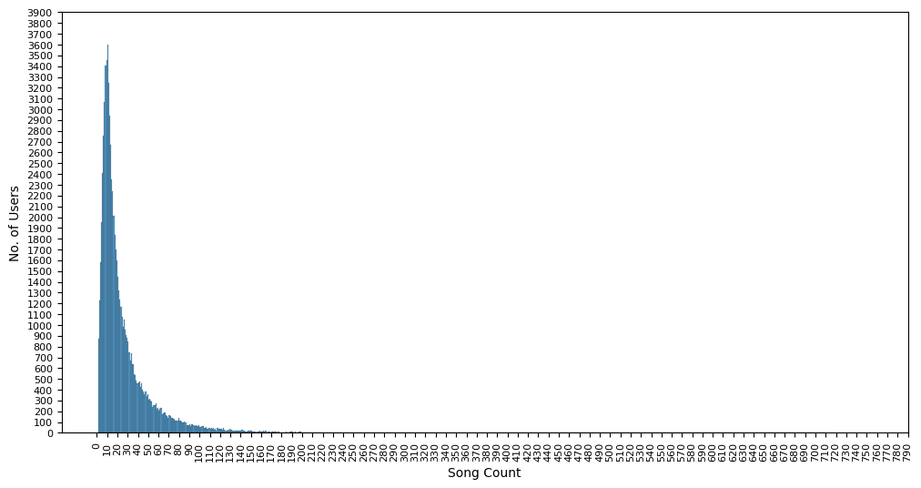

```python
# Show the song count distribution among users
user_song_count = pd.DataFrame(list(playing_count.items()), columns=['user_id', 'song_count'])

plt.figure(figsize=(12, 6))
sns.histplot(data=user_song_count, x='song_count', binwidth=1)
plt.locator_params(axis='x', nbins=15)
plt.xlabel('Song Count', fontsize=10)
plt.ylabel('No. of Users', fontsize=10)
plt.xticks(fontsize=8, rotation=90)
# Set x-ticks at specific intervals
ax = plt.gca()
ax.set_xticks(np.arange(0, 800, 10))
plt.yticks(fontsize=8)
ax.set_yticks(np.arange(0, 4000, 100))
plt.show()
```

```python
# Find the cutoff point for users
user_song_count.describe(percentiles=[0.25, 0.5, 0.75, 0.9, 0.95])
```

|  | user_id | song_count |
| --- | --- | --- |
| count | 76353.000000 | 76353.000000 |
| mean | 38176.000000 | 26.194125 |
| std | 22041.356889 | 31.625078 |
| min | 0.000000 | 1.000000 |
| 25% | 19088.000000 | 9.000000 |
| 50% | 38176.000000 | 16.000000 |
| 75% | 57264.000000 | 31.000000 |
| 90% | 68716.800000 | 58.000000 |
| 95% | 72534.400000 | 82.000000 |
| max | 76352.000000 | 711.000000 |

- **Choose 90 songs as cut off point. They're the top 5% users who demonstrate higher music consumption.**

```python
# We want our users to have listened at least 90 songs
SONG_COUNT_CUTOFF = 90

# Create a list of users who need to be removed
remove_users = []

for user, num_songs in playing_count.items():

    if num_songs < SONG_COUNT_CUTOFF:
        remove_users.append(user)

df = df.loc[ ~ df.user_id.isin(remove_users)]
```

**Locate the popular songs.**

```python
# Get the column containing the songs
songs = df.song_id

# Create a dictionary that maps songs to its number of users(listeners)
playing_count = dict()

for song in songs:
    # If we already have the song, just add 1 to their playing count
    if song in playing_count:
        playing_count[song] += 1

    # Otherwise, set their playing count to 1
    else:
        playing_count[song] = 1
```

```python
# Find the cutoff point for songs
song_user_count = pd.DataFrame(list(playing_count.items()), columns=['song_id', 'user_count'])
song_user_count.describe(percentiles=[0.25, 0.5, 0.75, 0.9, 0.95])
```

|  | song_id | user_count |
| --- | --- | --- |
| count | 9999.000000 | 9999.000000 |
| mean | 4999.921892 | 43.843384 |
| std | 2886.731741 | 61.097472 |
| min | 0.000000 | 1.000000 |
| 25% | 2500.500000 | 16.000000 |
| 50% | 5000.000000 | 26.000000 |
| 75% | 7499.500000 | 48.000000 |
| 90% | 8999.200000 | 86.000000 |
| 95% | 9499.100000 | 126.000000 |
| max | 9999.000000 | 1002.000000 |

```python
# We want our song to be listened by atleast 120 users to be considred
LISTENER_COUNT_CUTOFF = 120

remove_songs = []

for song, num_users in playing_count.items():
    if num_users < LISTENER_COUNT_CUTOFF:
        remove_songs.append(song)

df_final= df.loc[ ~ df.song_id.isin(remove_songs)]
```

```python
# Check df_final record numbers
df_final.info()
```

```
<class 'pandas.core.frame.DataFrame'>
Index: 130398 entries, 200 to 1999765
Data columns (total 7 columns):
 #   Column       Non-Null Count   Dtype
---  ------       --------------   -----
 0   user_id      130398 non-null  int64
 1   song_id      130398 non-null  int64
 2   play_count   130398 non-null  int64
 3   title        130398 non-null  object
 4   release      130398 non-null  object
 5   artist_name  130398 non-null  object
 6   year         130398 non-null  int64
dtypes: int64(4), object(3)
memory usage: 8.0+ MB
```

**As we do not have ratings data of the songs. In this case, we are going to use play_count as a proxy for ratings with the assumption that the more the user listens to a song, the higher the chance that they like the song. We need to check the play_count values distribution.**

```python
# Find the distribution of play_count values
df_final['play_count'].describe(percentiles=[0.25, 0.5, 0.75, 0.9, 0.95])
```

```
count    130398.000000
mean          2.682173
std           4.927500
min           1.000000
25%           1.000000
50%           1.000000
75%           3.000000
90%           5.000000
95%           8.000000
max         405.000000
Name: play_count, dtype: float64
```

Out of all the songs available, songs with play_count less than or equal to 5 are in almost 90% abundance. So for building the recommendation system let us consider only those songs. The outliers, such as users who have listened to a song an excessively high number of times, can skew the analysis.

```python
# Keep only records of songs with play_count less than or equal to (<=) 5
df_final = df_final[df_final.play_count<=5]
```

```python
# Check the shape of the data
df_final.shape
```

```
(117876, 7)
```

```python
# Remove those song_id records which do not appear in df_final
song_df = song_df[song_df['song_id'].isin(df_final['song_id'])]

# Check song_df info afterwards
song_df.info()
```

```
<class 'pandas.core.frame.DataFrame'>
Index: 563 entries, 2239 to 998484
Data columns (total 5 columns):
 #   Column       Non-Null Count  Dtype
---  ------       --------------  -----
 0   song_id      563 non-null    int64
 1   title        563 non-null    object
 2   release      563 non-null    object
 3   artist_name  563 non-null    object
 4   year         563 non-null    int64
dtypes: int64(2), object(3)
memory usage: 26.4+ KB
```

## **Exploratory Data Analysis**

### **Let's check the total number of unique users, songs, artists in the data**

Total number of unique user id

```python
# Display total number of unique user_id
df_final['user_id'].nunique()
```

```
3155
```

Total number of unique song id

```python
# Display total number of unique song_id
df_final['song_id'].nunique()
```

```
563
```

Total number of unique artists

```python
# Display total number of unique artists
df_final['artist_name'].nunique()
```

```
232
```

#### **Observations and Insights:**

**We trim down the dataset to only consider:**

1. users have listened to at least 90 songs (high-engagement user)
2. songs have been listened by at least 120 users (high-quality music)
3. play count less than or equal to 5 (excluding outliers which can skew the analysis)

After the trimming process, the dataset has been condensed to encompass **110,000+ user interactions** involving **560+ songs, 230+ artists and 3000+ users**. This refined dataset provides a more manageable and computationally efficient foundation for constructing recommendation systems.

Based on the count of unique users and songs, there exists a potential for 1,776,265 interactions (3155 users * 563 songs) within the dataset. However, the actual recorded interactions amount to only 117,876, representing approximately **6.6%** of the total potential interactions. This discrepancy underscores the reality that not every user has engaged with every song in the dataset, a common occurrence in such datasets.

While this presents an opportunity to develop recommendation systems for suggesting songs that users have yet to interact with, it also introduces **the challenge of data sparsity**. Addressing this challenge will be paramount in ensuring the efficacy and relevance of the recommendation algorithms.

### **Let's find out about the most interacted songs and interacted users**

Most interacted songs

```python
# Counting the number of users who have listened to a certain song
song_user_count = pd.DataFrame(df_final['song_id'].value_counts())

# Merge with song_df to show the most interacted songs' info
song_user_count_with_title = pd.merge(song_user_count,song_df, on = 'song_id', how = 'left')
song_user_count_with_title
```

|  | song_id | count | title | release | artist_name | year |
| --- | --- | --- | --- | --- | --- | --- |
| 0 | 8582 | 751 | Use Somebody | Use Somebody | Kings Of Leon | 2008 |
| 1 | 352 | 748 | Dog Days Are Over (Radio Edit) | Now That's What I Call Music! 75 | Florence + The Machine | 0 |
| 2 | 2220 | 713 | Sehr kosmisch | Musik von Harmonia | Harmonia | 0 |
| 3 | 1118 | 662 | Clocks | A Rush Of Blood To The Head | Coldplay | 2002 |
| 4 | 4152 | 652 | The Scientist | The Scientist | Coldplay | 2002 |
| ... | ... | ... | ... | ... | ... | ... |
| 558 | 9048 | 103 | Who's Real | The Last Kiss | Jadakiss / Swizz Beatz / OJ Da Juiceman | 2009 |
| 559 | 6450 | 102 | Brave The Elements | Brave The Elements - EP | Colossal | 0 |
| 560 | 990 | 101 | Creil City | Fat Come Back | Alliance Ethnik | 1999 |
| 561 | 4831 | 97 | Heaven Must Be Missing An Angel | Capitol Gold: The Best Of Tavares | Tavares | 1979 |
| 562 | 8324 | 96 | The Big Gundown | Invaders Must Die Remixes and Bonus Tracks | The Prodigy | 2009 |

563 rows × 6 columns

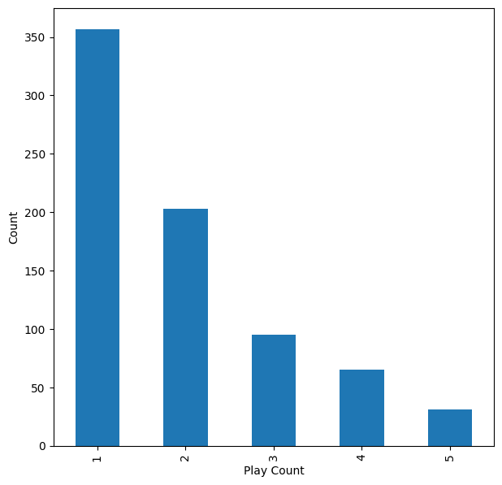

```python
# Plotting distributions of play_count for 751 interactions with song_id 8582

# Let us fix the size of the figure
plt.figure(figsize = (7, 7))

df_final[df_final['song_id'] == 8582]['play_count'].value_counts().plot(kind = 'bar')

# This gives a label to the variable on the x-axis
plt.xlabel('Play Count')

# This gives a label to the variable on the y-axis
plt.ylabel('Count')

# This displays the plot
plt.show()
```

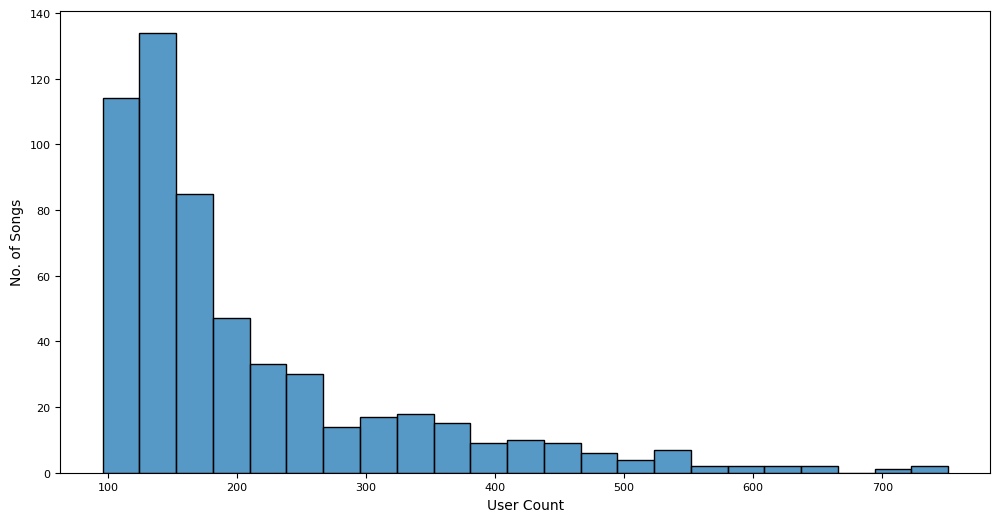

```python
# Show the user count distribution among songs

plt.figure(figsize=(12, 6))
sns.histplot(data=song_user_count, x='count')
plt.xlabel('User Count', fontsize=10)
plt.ylabel('No. of Songs', fontsize=10)
plt.xticks(fontsize=8)
plt.yticks(fontsize=8)
plt.show()
```

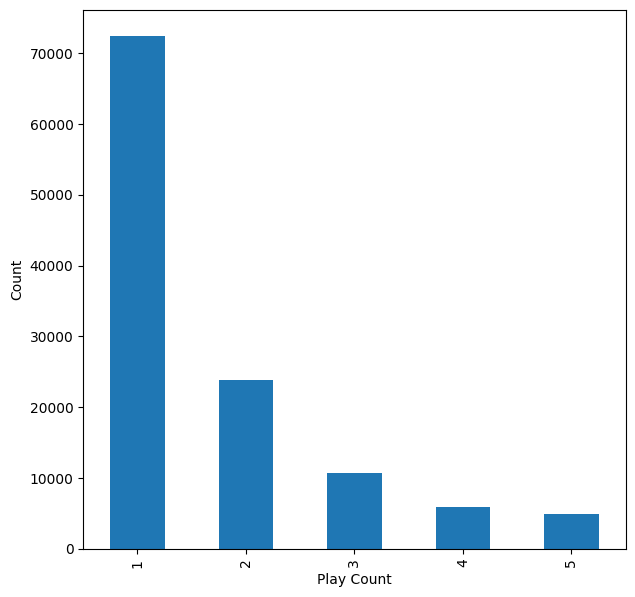

```python
# Plotting distributions of play_count for all interactions with all song_id

# Let us fix the size of the figure
plt.figure(figsize = (7, 7))

df_final['play_count'].value_counts().plot(kind = 'bar')

# This gives a label to the variable on the x-axis
plt.xlabel('Play Count')

# This gives a label to the variable on the y-axis
plt.ylabel('Count')

# This displays the plot
plt.show()
```

Most interacted users

```python
# Counting the number of songs which have been listened by a certain user to show the most interacted users
user_song_count = pd.DataFrame(df_final['user_id'].value_counts())
user_song_count
```

| user_id | count |
| --- | --- |
| 61472 | 243 |
| 15733 | 227 |
| 37049 | 202 |
| 9570 | 184 |
| 23337 | 177 |
| ... | ... |
| 19776 | 1 |
| 45476 | 1 |
| 17961 | 1 |
| 14439 | 1 |
| 10412 | 1 |

3155 rows × 1 columns

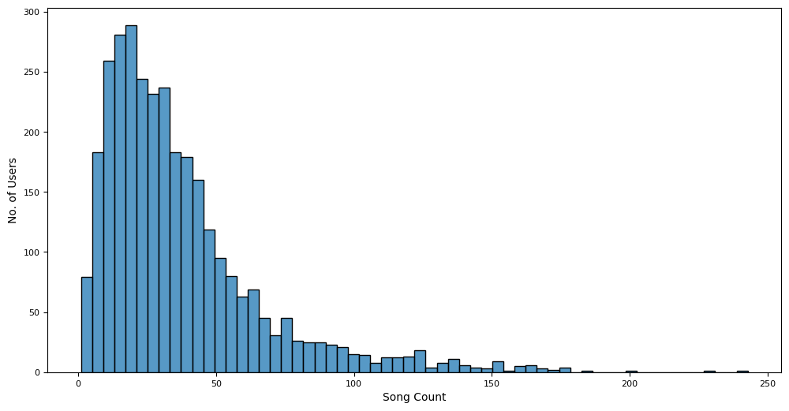

```python
# Show the song count distribution among users

plt.figure(figsize=(12, 6))
sns.histplot(data=user_song_count, x='count')
plt.xlabel('Song Count', fontsize=10)
plt.ylabel('No. of Users', fontsize=10)
plt.xticks(fontsize=8)
plt.yticks(fontsize=8)
plt.show()
```

#### **Observations and Insights:**

- The most interacted song has 751 users.
- The most interacted user listened to 243 songs.
- Among the 110,000+ interactions, the majorities' play count fall between 1 and 2. Over 70000 have play count as 1, Over 20000 have play count as 2, only around 5000 have play count as 5.
- No matter songs, users or interaction play counts, they all follow the power law, ie. a small number of items (songs, users, or interaction play counts) account for the majority of the occurrences, while the majority of items have relatively low frequencies. For example, a few popular songs have a lot of interactions, while the majority of songs have a lot fewer.
- It underscores the complexities associated with data sparsity and the importance of mitigating potential biases inherent in the recommendation algorithm.

Songs released on yearly basis

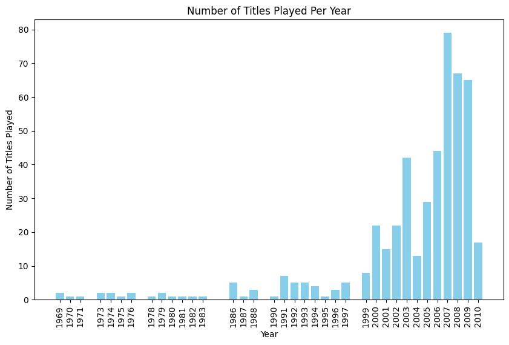

```python
# Find out the number of songs released in a year, use the songs_df
  # Hint: Use groupby function on the 'year' column

  # Group by 'year' and count occurrences of 'song_id'
yearly_song_counts = song_df.groupby(by='year')['song_id'].count()

# Convert the Series to a DataFrame and reset the index
yearly_song_counts = yearly_song_counts.reset_index()

# Rename the columns for clarity
yearly_song_counts.columns = ['year', 'count']

# Filter out rows where 'year' is 0
yearly_song_counts = yearly_song_counts[yearly_song_counts['year'] != 0]

# Set the figure size
plt.figure(figsize=(10, 6))

# Create a barplot plot with y label as "number of titles played" and x -axis year
plt.bar(yearly_song_counts['year'], yearly_song_counts['count'], color='skyblue',width=0.8)

# Set the x label of the plot
plt.xlabel('Year')
plt.xticks(yearly_song_counts['year'],rotation=90)  # Ensure all years are shown on x-axis

# Set the y label of the plot
plt.ylabel('Number of Titles Played')

# Show the plot
plt.title('Number of Titles Played Per Year')
plt.show()
```

Songs' user count by song release year

```python
# Group by year and count unique user_id
user_count_by_year = df_final.groupby('year')['user_id'].nunique().reset_index()
# Filter out rows where 'year' is 0
user_count_by_year = user_count_by_year[user_count_by_year['year'] != 0]
```

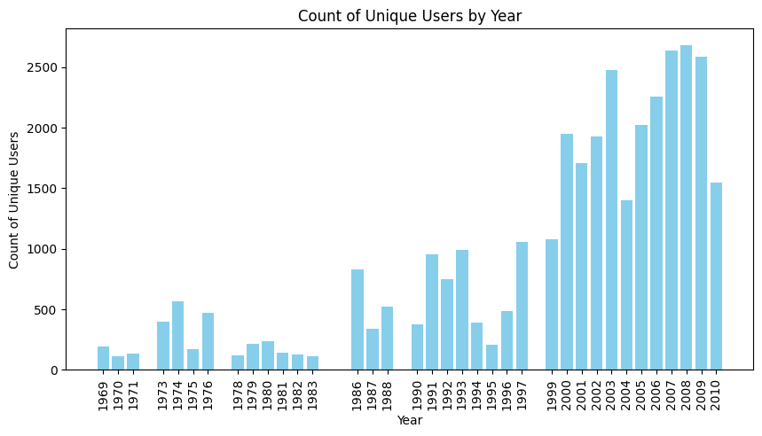

```python
# Plot the barplot
plt.figure(figsize=(10, 5))
plt.bar(user_count_by_year['year'], user_count_by_year['user_id'], color='skyblue')
plt.xlabel('Year')
plt.xticks(user_count_by_year['year'],rotation=90)  # Ensure all years are shown on x-axis
plt.ylabel('Count of Unique Users')
plt.title('Count of Unique Users by Year')
plt.xticks(user_count_by_year['year'])
plt.show()
```

Songs' total play count by song release year

```python
song_year_play_count = df_final.groupby('year')['play_count'].sum().reset_index()
# Filter out rows where 'year' is 0
song_year_play_count = song_year_play_count[song_year_play_count['year'] != 0]
```

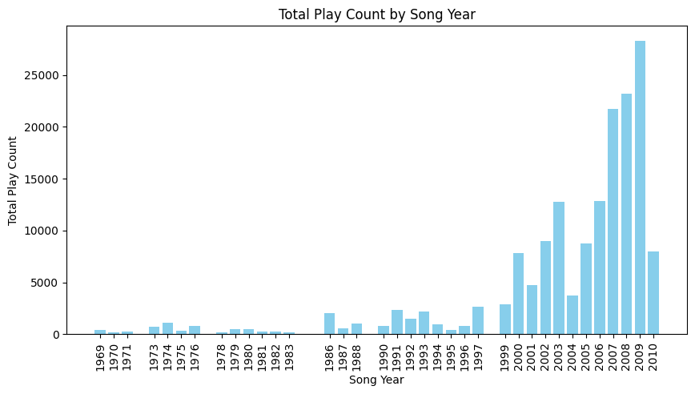

```python
# Plot the barplot
plt.figure(figsize=(10, 5))
plt.bar(song_year_play_count['year'], song_year_play_count['play_count'], color='skyblue')
plt.xlabel('Song Year')
plt.xticks(song_year_play_count['year'],rotation=90)  # Ensure all years are shown on x-axis
plt.ylabel('Total Play Count')
plt.title('Total Play Count by Song Year')
plt.show()
```

Artists having most songs

```python
# Counting the number of songs for each artist
song_df['artist_name'].value_counts()
```

```
artist_name
The Killers                                22
Coldplay                                   19
LCD Soundsystem                            16
the bird and the bee                       15
Octopus Project                            12
                                           ..
Triumvirat                                  1
Soundgarden                                 1
Foolish Things                              1
Cat Stevens                                 1
Drake / Kanye West / Lil Wayne / Eminem     1
Name: count, Length: 232, dtype: int64
```

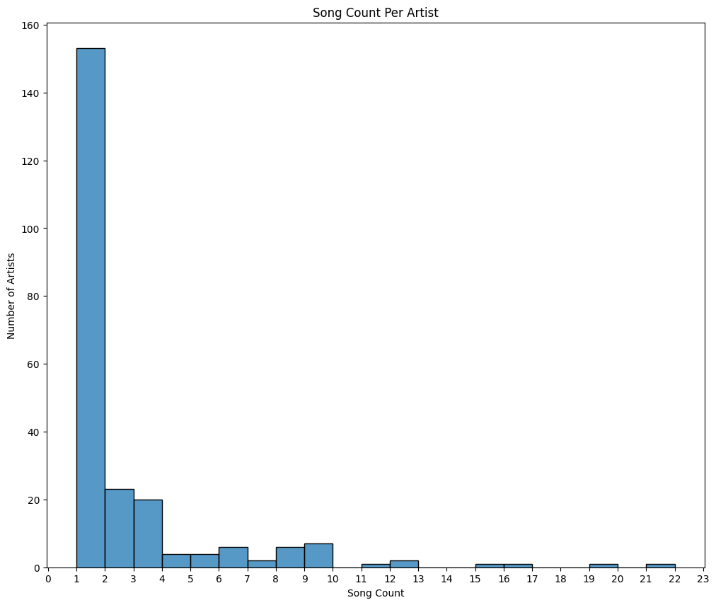

```python
# song artist analysis

# Group by 'artist_name' and count occurrences of 'song_id'
artist_song_counts = song_df.groupby(by='artist_name')['song_id'].count()

# Convert the Series to a DataFrame and reset the index
artist_song_counts = artist_song_counts.reset_index()

# Rename the columns for clarity
artist_song_counts.columns = ['artist_name', 'song_count']

# Set the figure size
plt.figure(figsize=(12, 10))

# Create a histplot with y label as "Number of Artists" and x -axis Song Count

sns.histplot(data=artist_song_counts, x='song_count', binwidth=1)
plt.locator_params(axis='x', nbins=25)

# Set the x label of the plot
plt.xlabel('Song Count')

# Set the y label of the plot
plt.ylabel('Number of Artists')

# Show the plot
plt.title('Song Count Per Artist')
plt.show()
```

Artists having most users

```python
user_count_by_artist = df_final.groupby('artist_name')['user_id'].nunique().reset_index()
user_count_by_artist = user_count_by_artist.sort_values(by='user_id', ascending=False)
user_count_by_artist
```

|  | artist_name | user_id |
| --- | --- | --- |
| 40 | Coldplay | 1405 |
| 192 | The Killers | 1343 |
| 113 | Kings Of Leon | 1251 |
| 73 | Florence + The Machine | 1078 |
| 225 | Vampire Weekend | 929 |
| ... | ... | ... |
| 91 | Interpol | 107 |
| 95 | Jadakiss / Swizz Beatz / OJ Da Juiceman | 103 |
| 41 | Colossal | 102 |
| 184 | Tavares | 97 |
| 198 | The Prodigy | 96 |

232 rows × 2 columns

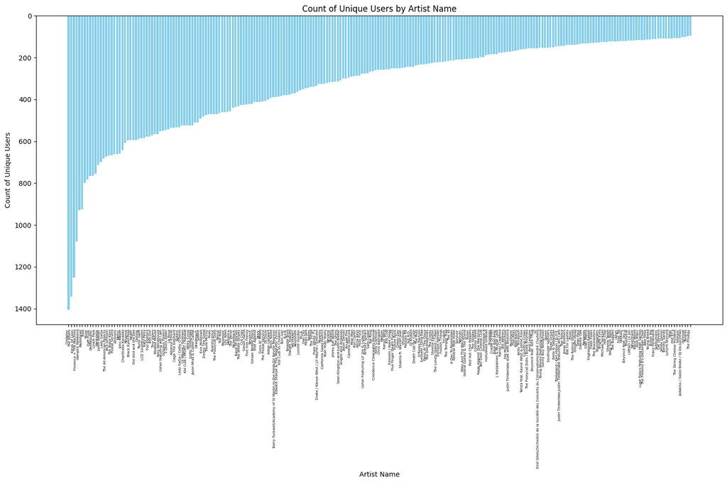

```python
plt.figure(figsize=(15, 10))
plt.bar(user_count_by_artist['artist_name'], user_count_by_artist['user_id'], color='skyblue')
plt.xlabel('Artist Name')
plt.ylabel('Count of Unique Users')
plt.title('Count of Unique Users by Artist Name')
plt.xticks(rotation=90, ha='right', fontsize=5)
plt.tight_layout()  # Adjust layout to make room for rotated labels
plt.gca().invert_yaxis()  # Invert y-axis to have the largest bar at the top
plt.show()
```

Artists having most play count

```python
play_count_by_artist = df_final.groupby('artist_name')['play_count'].sum().reset_index()
play_count_by_artist = play_count_by_artist.sort_values(by='play_count', ascending=False)
play_count_by_artist
```

|  | artist_name | play_count |
| --- | --- | --- |
| 40 | Coldplay | 9049 |
| 192 | The Killers | 6152 |
| 73 | Florence + The Machine | 5422 |
| 113 | Kings Of Leon | 4855 |
| 103 | Justin Bieber | 3496 |
| ... | ... | ... |
| 229 | Young Bleed | 176 |
| 182 | Subhumans | 171 |
| 197 | The Pretend It's December Choir | 161 |
| 91 | Interpol | 160 |
| 20 | Beyoncé feat. Jay-Z | 157 |

232 rows × 2 columns

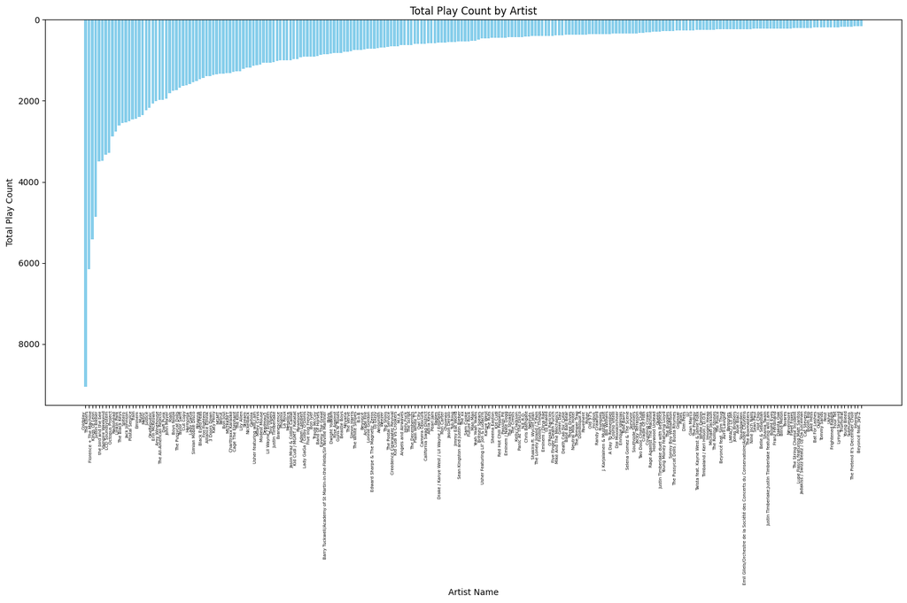

```python
# Plot the barplot
plt.figure(figsize=(15, 10))
plt.bar(play_count_by_artist['artist_name'], play_count_by_artist['play_count'], color='skyblue')
plt.xlabel('Artist Name')
plt.xticks(play_count_by_artist['artist_name'],rotation=90)  # Ensure all artist name are shown on x-axis
plt.ylabel('Total Play Count')
plt.title('Total Play Count by Artist')
plt.xticks(rotation=90, ha='right', fontsize=5)
plt.tight_layout()  # Adjust layout to make room for rotated labels
plt.gca().invert_yaxis()  # Invert y-axis to have the largest bar at the top
plt.show()
```

Release having most play count

```python
release_play_count = df_final.groupby('release')['play_count'].sum().reset_index()
release_play_count = release_play_count.sort_values(by='play_count', ascending=False)
release_play_count
```

|  | release | play_count |
| --- | --- | --- |
| 198 | My Worlds | 2862 |
| 173 | Lungs | 2713 |
| 334 | Vampire Weekend | 2653 |
| 244 | Ray Guns Are Not Just The Future | 2639 |
| 120 | Hell Train | 2538 |
| ... | ... | ... |
| 150 | It's Christmas So We'll Stop | 161 |
| 125 | Hip Hop The Collection 2009 | 161 |
| 16 | Antics | 160 |
| 63 | Dangerously In Love | 157 |
| 136 | If Looks Could Kill | 146 |

369 rows × 2 columns

Release having most users

```python
user_count_by_release = df_final.groupby('release')['user_id'].nunique().reset_index()
user_count_by_release = user_count_by_release.sort_values(by='user_id', ascending=False)
user_count_by_release
```

|  | release | user_id |
| --- | --- | --- |
| 209 | Now That's What I Call Music! 75 | 846 |
| 6 | A Rush Of Blood To The Head | 843 |
| 334 | Vampire Weekend | 836 |
| 340 | Waking Up | 764 |
| 224 | Only By The Night | 763 |
| ... | ... | ... |
| 126 | Hit By A Train: The Best Of Old 97's | 107 |
| 300 | The Last Kiss | 103 |
| 39 | Brave The Elements - EP | 102 |
| 44 | Capitol Gold: The Best Of Tavares | 97 |
| 147 | Invaders Must Die Remixes and Bonus Tracks | 96 |

369 rows × 2 columns

Release having most songs (remember in our dataset these songs are already been selected as more popular ones)

```python
release_song_count = song_df.groupby('release')['song_id'].count().reset_index()
release_song_count = release_song_count.sort_values(by='song_id', ascending=False)
release_song_count
```

|  | release | song_id |
| --- | --- | --- |
| 244 | Ray Guns Are Not Just The Future | 12 |
| 120 | Hell Train | 9 |
| 108 | Give Up | 9 |
| 334 | Vampire Weekend | 8 |
| 161 | LCD Soundsystem | 7 |
| ... | ... | ... |
| 137 | If There Was A Way | 1 |
| 136 | If Looks Could Kill | 1 |
| 134 | I Need A Dollar | 1 |
| 132 | Hustler | 1 |
| 368 | À La Carte | 1 |

369 rows × 2 columns

Years having most release

```python
release_year_count = song_df.groupby('year')['release'].nunique().reset_index()
release_year_count = release_year_count[release_year_count['year'] != 0].sort_values(by='release', ascending=False)
release_year_count
```

|  | year | release |
| --- | --- | --- |
| 33 | 2007 | 49 |
| 35 | 2009 | 44 |
| 34 | 2008 | 40 |
| 32 | 2006 | 31 |
| 29 | 2003 | 29 |
| 31 | 2005 | 17 |
| 28 | 2002 | 14 |
| 26 | 2000 | 14 |
| 27 | 2001 | 13 |
| 36 | 2010 | 12 |
| 30 | 2004 | 10 |
| 18 | 1991 | 7 |
| 25 | 1999 | 7 |
| 24 | 1997 | 5 |
| 20 | 1993 | 5 |
| 19 | 1992 | 5 |
| 14 | 1986 | 5 |
| 21 | 1994 | 3 |
| 23 | 1996 | 3 |
| 16 | 1988 | 3 |
| 1 | 1969 | 2 |
| 9 | 1979 | 2 |
| 4 | 1973 | 2 |
| 5 | 1974 | 2 |
| 7 | 1976 | 2 |
| 3 | 1971 | 1 |
| 6 | 1975 | 1 |
| 8 | 1978 | 1 |
| 17 | 1990 | 1 |
| 10 | 1980 | 1 |
| 12 | 1982 | 1 |
| 13 | 1983 | 1 |
| 22 | 1995 | 1 |
| 15 | 1987 | 1 |
| 2 | 1970 | 1 |
| 11 | 1981 | 1 |

Artists having most release

```python
artist_release_count = song_df.groupby('artist_name')['release'].nunique().reset_index()
artist_release_count = artist_release_count.sort_values(by='release', ascending=False)
artist_release_count
```

|  | artist_name | release |
| --- | --- | --- |
| 40 | Coldplay | 12 |
| 192 | The Killers | 8 |
| 114 | LCD Soundsystem | 7 |
| 187 | The Black Keys | 6 |
| 7 | Amy Winehouse | 6 |
| ... | ... | ... |
| 37 | Charttraxx Karaoke | 1 |
| 115 | LMFAO / Lil Jon | 1 |
| 1 | A Day To Remember | 1 |
| 117 | La Roux | 1 |
| 116 | LU | 1 |

232 rows × 2 columns

#### **Observations and Insights:**

- The Million Song Dataset released in 2011. That explains most of the songs in the dataset comes from 2000-2010.
- The artists and their no. of songs follow the power law too. A few popular artists have more songs, while the majority only have relatively low no. of songs.
- We do further analysis to find the popular artists and releases.

**Think About It:** What other insights can be drawn using exploratory data analysis?

If have more time, we can consider to do further analysis on play count distribution among artists.

Now that we have explored the data, let's apply different algorithms to build recommendation systems.

**Note:** Use the shorter version of the data, i.e., the data after the cutoffs as used in Milestone 1.

## Building various models

### **Popularity-Based Recommendation Systems**

```python
# Calculating average play_count
       # Hint: Use groupby function on the song_id column
average_count = df_final.groupby('song_id')['play_count'].mean()

# Calculating the frequency a song is played
      # Hint: Use groupby function on the song_id column
play_freq = df_final.groupby('song_id')['play_count'].count()
```

```python
# Making a dataframe with the average_count and play_freq
final_play = pd.DataFrame({'average_count': average_count, 'play_freq': play_freq})

# Let us see the first five records of the final_play dataset
final_play.head()
```

| song_id | average_count | play_freq |
| --- | --- | --- |
| 21 | 1.622642 | 265 |
| 22 | 1.492424 | 132 |
| 52 | 1.729216 | 421 |
| 62 | 1.728070 | 114 |
| 93 | 1.452174 | 115 |

```python
# Build the function to find top n songs based on the highest average rating and minimum interactions
def top_n_songs(data, n, min_interaction = 100):

# Finding products with minimum number of interactions
    recommendations = data[data['play_freq'] > min_interaction]

# Sorting values with respect to average play
    recommendations = data.sort_values(by = 'average_count', ascending = False)

    return recommendations.index[:n]
```

```python
# Recommend top 10 songs using the function defined above
list(top_n_songs(final_play, 10))
```

```
[7224, 8324, 6450, 9942, 5531, 5653, 8483, 2220, 657, 614]
```

**Let's define a data frame to save the models' metrics for later comparision.**

```python
# Define the columns for the DataFrame to save model's info
df_model_info_columns = ['Model Type', 'Parameters', 'Precision', 'Recall', 'F1', 'RMSE', 'Combination']

# Create an empty DataFrame with the specified columns
df_model_info = pd.DataFrame(columns=df_model_info_columns)

# Function to add a new model record to the DataFrame
def add_model_record(df, model_type, parameters, precision, recall, f1, rmse, model_combination=''):
    new_record = {
        'Model Type': model_type,
        'Parameters': parameters,
        'Precision': precision,
        'Recall': recall,
        'F1': f1,
        'RMSE': rmse,
        'Combination': model_combination
    }
    df.loc[len(df)] = new_record
```

### **User User Similarity-Based Collaborative Filtering**

To build the user-user-similarity-based and subsequent models we will use the "surprise" library.

```python
# Install the surprise package using pip. Uncomment and run the below code to do the same

!pip install surprise
```

```python
# Import necessary libraries

# To compute the accuracy of models
from surprise import accuracy

# This class is used to parse a file containing play_counts, data should be in structure - user; item; play_count
from surprise.reader import Reader

# Class for loading datasets
from surprise.dataset import Dataset

# For tuning model hyperparameters
from surprise.model_selection import GridSearchCV

# For splitting the data in train and test dataset
from surprise.model_selection import train_test_split

# For implementing similarity-based recommendation system
from surprise.prediction_algorithms.knns import KNNBasic

# For implementing matrix factorization based recommendation system
from surprise.prediction_algorithms.matrix_factorization import SVD

# For implementing KFold cross-validation
from surprise.model_selection import KFold

# For implementing clustering-based recommendation system
from surprise import CoClustering
```

### Some useful functions

Below is the function to calculate precision@k and recall@k, RMSE, and F1_Score@k to evaluate the model performance.

**Think About It:** Which metric should be used for this problem to compare different models?

- Precision is the proportion of recommended items that are relevant. Higher precision will have better user experience. If users have to sift through many irrelevant recommendations, their satisfaction may decrease.
- Recall is the proportion of relevant items that are recommended. Higher recall will help users discover as much new and relevant content as possible. It can lead to more engagement, as users find more songs that they enjoy. This is particularly important in competitive markets where retaining user attention is crucial.
- F1-score is the harmonic mean of precision and recall, providing a single metric that balances the two. It’s particularly useful when both precision and recall are important and a trade-off needs to be considered.

```python
def precision_recall_at_k(model, k=30, threshold=1.5):
    """Return precision and recall at k metrics for each user"""

    # First map the predictions to each user.
    user_est_true = defaultdict(list)

    #Making predictions on the test data
    predictions = model.test(testset)

    for uid, _, true_r, est, _ in predictions:
        user_est_true[uid].append((est, true_r))

    precisions = dict()
    recalls = dict()
    for uid, playing_count in user_est_true.items():

        # Sort play count by estimated value
        playing_count.sort(key=lambda x: x[0], reverse=True)

        # Number of relevant items
        n_rel = sum((true_r >= threshold) for (_, true_r) in playing_count)

        # Number of recommended items in top k
        n_rec_k = sum((est >= threshold) for (est, _) in playing_count[:k])

        # Number of relevant and recommended items in top k
        n_rel_and_rec_k = sum(((true_r >= threshold) and (est >= threshold))
                              for (est, true_r) in playing_count[:k])

        # Precision@K: Proportion of recommended items that are relevant
        # When n_rec_k is 0, Precision is undefined. We here set Precision to 0 when n_rec_k is 0.

        precisions[uid] = n_rel_and_rec_k / n_rec_k if n_rec_k != 0 else 0

        # Recall@K: Proportion of relevant items that are recommended
        # When n_rel is 0, Recall is undefined. We here set Recall to 0 when n_rel is 0.

        recalls[uid] = n_rel_and_rec_k / n_rel if n_rel != 0 else 0

    #Mean of all the predicted precisions are calculated.
    precision = round((sum(prec for prec in precisions.values()) / len(precisions)),8)
    #Mean of all the predicted recalls are calculated.
    recall = round((sum(rec for rec in recalls.values()) / len(recalls)),8)
    # Formula to compute the F-1 score.
    f1 = round((2*precision*recall)/(precision+recall),8)
    # Retrieve RMSE and print
    rmse = round(accuracy.rmse(predictions),8)

    print('Precision: ', precision) #Command to print the overall precision
    print('Recall: ', recall) #Command to print the overall recall
    print('F_1 score: ', f1) #Command to print the F-1 score

    # Return all 4 scores
    return precision, recall, f1, rmse
```

**Think About It:** In the function precision_recall_at_k above the threshold value used is 1.5. How precision and recall are affected by changing the threshold? What is the intuition behind using the threshold value of 1.5?

- Precision: Precision measures the proportion of recommended items that are relevant to the user out of all recommended items. When the threshold is increased, it becomes harder for items to be considered relevant, leading to potentially fewer true positives (relevant items) being recommended. However, because the number of false positives (irrelevant items) decreases more significantly, the precision typically increases as the threshold increases, making the algorithm more conservative in its recommendations.
- Recall: Recall measures the proportion of relevant items that are successfully recommended out of all relevant items in the dataset. Increasing the threshold causes the algorithm to be more selective in recommending items, potentially missing some relevant items that would have been recommended with a lower threshold. This leads to an increase in false negatives and consequently a decrease in recall as the threshold increases, because the algorithm may overlook some relevant items.
- The selection of the threshold value, specifically 1.5 in our case, corresponds to the play count criterion within our dataset. In above data analysis, the majority fall between 1 and 2, a threshold of 1.5 helps filter out items that are not strongly relevant while keeping those that are most likely to be of interest. Given that this threshold represents a play count above which a song is considered significant (rounded to 2 for practical application), it signifies instances where a user has played a song more than once. The rationale behind this choice stems from the recognition of our dataset's sparsity, necessitating a cautious balance in recommendation strategies. Opting for a threshold lower than 1.5 could potentially result in an overabundance of irrelevant song recommendations, which would compromise the effectiveness of our recommendation system.

Below we are loading the **dataset**, which is a **pandas dataframe**, into a **different format called `surprise.dataset.DatasetAutoFolds`** which is required by this library. To do this we will be **using the classes `Reader` and `Dataset`**

You will also notice here that we read the dataset by providing a scale of ratings. However, as you would know, we do not have ratings data of the songs. In this case, we are going to use play_count as a proxy for ratings with the assumption that the more the user listens to a song, the higher the chance that they like the song.

```python
# Instantiating Reader scale with expected rating scale
 #use rating scale (0, 5)
reader = Reader(rating_scale = (0, 5))

# Loading the dataset
 # Take only "user_id","song_id", and "play_count"
data = Dataset.load_from_df(df_final[['user_id', 'song_id', 'play_count']], reader)

# Splitting the data into train and test dataset
 # Take test_size = 0.4, random_state = 42
trainset, testset = train_test_split(data, test_size = 0.4, random_state = 42)
```

**Think About It:** How changing the test size would change the results and outputs?

- As the test size increases, the proportion of data available for training decreases. This could potentially impact the model's ability to learn from the training data, especially if the training set becomes too small. With a smaller training set, the model may not capture the underlying patterns in the data as effectively, which could lead to poorer performance.
- But a larger test size means more data is held out for evaluation, providing a more reliable estimate of how well the model will perform on unseen data.
- A smaller test size may lead to higher variance because the evaluation of model performance is more sensitive to the specific random split of the data. Conversely, a larger test size may lead to higher bias because the model has less data for training and may generalize less effectively to unseen data.

In summary, changing the test size when splitting the data can impact the trade-off between training and testing performance, generalization ability, bias and variance, and the robustness of the results.

```python
# Build the default user-user-similarity model
sim_options = {'name': 'cosine',
               'user_based': True}

# KNN algorithm is used to find desired similar items
 # Use random_state = 1
sim_user_user = KNNBasic(sim_options = sim_options, verbose = False, random_state = 1)

# Train the algorithm on the trainset, and predict play_count for the testset
sim_user_user.fit(trainset)
```

```
<surprise.prediction_algorithms.knns.KNNBasic at 0x7b83333d8130>
```

```python
# Let us compute precision@k, recall@k, and f_1 score with k = 30
# Use sim_user_user model
precision, recall, f1, rmse = precision_recall_at_k(sim_user_user)
# Save the model's info
sim_user_user_params = f"k={sim_user_user.k}, min_k={sim_user_user.min_k}, sim_options={sim_user_user.sim_options}, verbose={sim_user_user.verbose}"
add_model_record(df_model_info, 'User-User', sim_user_user_params, precision, recall, f1, rmse)
```

```
RMSE: 1.0878
Precision:  0.39619739
Recall:  0.69199544
F_1 score:  0.50389376
```

```python
# Check the model info dataframe
df_model_info
```

|  | Model Type | Parameters | Precision | Recall | F1 | RMSE | Combination |
| --- | --- | --- | --- | --- | --- | --- | --- |
| 0 | User-User | k=40, min_k=1, sim_options={'name': 'cosine', ... | 0.396197 | 0.691995 | 0.503894 | 1.087823 |  |

**Observations and Insights:**

```python
# Predicting play_count for a sample user with a listened song
# Use any user id  and song_id
sim_user_user.predict(6958, 1671, r_ui = 2, verbose = True)
```

```
user: 6958       item: 1671       r_ui = 2.00   est = 1.80   {'actual_k': 40, 'was_impossible': False}
```

```
Prediction(uid=6958, iid=1671, r_ui=2, est=1.8009387435128914, details={'actual_k': 40, 'was_impossible': False})
```

```python
# Predicting play_count for a sample user with a song not-listened by the user
 #predict play_count for any sample user
sim_user_user.predict(6958, 3232, verbose = True)
```

```
user: 6958       item: 3232       r_ui = None   est = 1.64   {'actual_k': 40, 'was_impossible': False}
```

```
Prediction(uid=6958, iid=3232, r_ui=None, est=1.6386860897998294, details={'actual_k': 40, 'was_impossible': False})
```

**Observations and Insights:**

- The above output shows that **the actual play count 2 is close to the predicted play count 1.8 for this user-item pair** by this **user-user-similarity-based baseline model**.
- The **output** also contains **"actual_k"**. It is the value of **K in KNN** that is used while training the model. The default value is 40.
- Above, we also **predicted the play count for a non-interacted user-item pair** based on this user-user similarity-based baseline model.

Now, let's try to tune the model and see if we can improve the model performance.

```python
# Setting up parameter grid to tune the hyperparameters
param_grid = {'k': [30, 40, 50], 'min_k': [3, 6, 9],
              'sim_options': {'name': ['msd', 'cosine'],
                              'user_based': [True]}
              }

# Performing 3-fold cross-validation to tune the hyperparameters
gs = GridSearchCV(KNNBasic, param_grid, measures = ['rmse'], cv = 3, n_jobs = -1)

# Fitting the data
 # Use entire data for GridSearch
gs.fit(data)

# Best RMSE score
print(gs.best_score['rmse'])

# Combination of parameters that gave the best RMSE score
print(gs.best_params['rmse'])
```

```
1.0579892307287253
{'k': 50, 'min_k': 9, 'sim_options': {'name': 'msd', 'user_based': True}}
```

```python
# Train the best model found in above gridsearch

# Using the optimal similarity measure for user-user based collaborative filtering
sim_options = {'name': 'msd',
               'user_based': True}

# Creating an instance of KNNBasic with optimal hyperparameter values
sim_user_user_optimized = KNNBasic(sim_options = sim_options, k = 50, min_k = 9, random_state = 1, verbose = False)

# Training the algorithm on the trainset
sim_user_user_optimized.fit(trainset)
```

```
<surprise.prediction_algorithms.knns.KNNBasic at 0x7b832aa802e0>
```

```python
# Let us compute precision@k and recall@k also with k =30
precision, recall, f1, rmse = precision_recall_at_k(sim_user_user_optimized)

# Save the model's info
sim_user_user_optimized_params = f"k={sim_user_user_optimized.k}, min_k={sim_user_user_optimized.min_k}, sim_options={sim_user_user_optimized.sim_options}, verbose={sim_user_user_optimized.verbose}"
add_model_record(df_model_info, 'User-User Optimized', sim_user_user_optimized_params, precision, recall, f1, rmse)
```

```
RMSE: 1.0596
Precision:  0.41430006
Recall:  0.62336636
F_1 score:  0.49777215
```

**Observations and Insights:**

- We can see from above that after tuning hyperparameters, **the RMSE of the model has gone down as compared to the model before hyperparameter tuning**. Along with this, **Precision score of the tuned model has increased in comparison to the baseline model**, but recall and F1 score went down. The model performance didn't improve much after hyperparameter tuning.

```python
# Predict the play count for a user who has listened to the song. Take user_id 6958, song_id 1671 and r_ui = 2
sim_user_user_optimized.predict(6958, 1671, r_ui = 2, verbose = True)
```

```
user: 6958       item: 1671       r_ui = 2.00   est = 1.53   {'actual_k': 50, 'was_impossible': False}
```

```
Prediction(uid=6958, iid=1671, r_ui=2, est=1.5325739475720954, details={'actual_k': 50, 'was_impossible': False})
```

```python
# Predict the play count for a song that is not listened to by the user (with user_id 6958)
sim_user_user_optimized.predict(6958, 3232, verbose = True)
```

```
user: 6958       item: 3232       r_ui = None   est = 1.44   {'actual_k': 45, 'was_impossible': False}
```

```
Prediction(uid=6958, iid=3232, r_ui=None, est=1.4402638185911276, details={'actual_k': 45, 'was_impossible': False})
```

**Observations and Insights:**

- The predicted play count by the tuned model varies from the prediction by the baseline model, deviating notably from the actual play count.

```python
# Use inner id 0
sim_user_user_optimized.get_neighbors(0, k = 5)
```

```
[31, 82, 90, 116, 125]
```

Below we will be implementing a function where the input parameters are:

- data: A **song** dataset
- user_id: A user-id **against which we want the recommendations**
- top_n: The **number of songs we want to recommend**
- algo: The algorithm we want to use **for predicting the play_count**
- The output of the function is a **set of top_n items** recommended for the given user_id based on the given algorithm

```python
def get_recommendations(data, user_id, top_n, algo):

    # Creating an empty list to store the recommended song ids
    recommendations = []

    # Creating an user item interactions matrix
    user_item_interactions_matrix = data.pivot(index = 'user_id', columns = 'song_id', values = 'play_count')

    # Extracting those song ids which the user_id has not played yet
    non_interacted_songs = user_item_interactions_matrix.loc[user_id][user_item_interactions_matrix.loc[user_id].isnull()].index.tolist()

    # Looping through each of the song ids which user_id has not interacted yet
    for song_id in non_interacted_songs:

        # Predicting the users for those non played song ids by this user
        est = algo.predict(user_id, song_id).est

        # Appending the predicted play_counts
        recommendations.append((song_id, est))

    # Sorting the predicted play_counts in descending order
    recommendations.sort(key = lambda x: x[1], reverse = True)

    return recommendations[:top_n] # Returing top n highest predicted play_count songs for this user
```

```python
# Make top 5 recommendations for any user_id with a similarity-based recommendation engine
recommendations = get_recommendations(df_final, 6958, 5, sim_user_user_optimized)
```

```python
# Building the dataframe for above recommendations with columns "song_id" and "predicted_play_count"
pd.DataFrame(recommendations, columns = ['song_id', 'predicted_play_count'])
```

|  | song_id | predicted_play_count |
| --- | --- | --- |
| 0 | 7224 | 2.935235 |
| 1 | 6450 | 2.668720 |
| 2 | 8324 | 2.467205 |
| 3 | 6448 | 2.386082 |
| 4 | 4831 | 2.348859 |

**Observations and Insights:**

- We implement a function to Make top n recommendations for any user id with a fitted model. It will return the song ids and predicted play counts.